# Compare OsteoCar references

Stephanie J. Spielman

2026-08-06

There are several different references in `OsteoCar`, and while we can generally map them to our sample properties, we have some samples which don’t neatly line up. For example, `OsteoCar` has patient primary and metastatic (lung only) references, but we have several samples from metastatic tissue in bone, which differs from the metastatic reference.

The goal of this notebook is to lightly compare some of the references:

- patient primary vs metastatic (lung only) references
- xenograft primary vs metastatic references

We compare the references to one another to see how similar the cell type distributions and expression signatures are. As these references are quite large, they have to be aggregated before use, but we’ll also explore their raw data too.

## Setup

```r
suppressPackageStartupMessages({
  library(SingleR)
  library(SingleCellExperiment)
  library(ggplot2)
  library(patchwork)
})
bp_param <- BiocParallel::MulticoreParam(6)
set.seed(2026)
```

```r
repository_base <- rprojroot::find_root(rprojroot::is_git_root)

module_dir <- file.path(repository_base, "analyses", "cell-type-osteosarcoma")
ref_dir <- file.path(module_dir, "references")
```

## Functions

```r
make_barplot <- function(prim_coldata, mets_coldata) {

  prim_table <- prim_coldata |>
    as.data.frame() |>
    dplyr::count(Ann_Level1, Ann_Level2) |>
    dplyr::mutate(ref = "primary")

  full_table <- mets_coldata |>
    as.data.frame() |>
    dplyr::count(Ann_Level1, Ann_Level2) |>
    dplyr::mutate(ref = "metastasis") |>
    dplyr::bind_rows(prim_table) |>
    dplyr::group_by(ref) |>
    dplyr::mutate(prop = n / sum(n)) |>
    dplyr::ungroup()

  p_counts <- ggplot(full_table) +
    aes(x = Ann_Level2, y = n, fill = ref) +
    geom_col(position = position_dodge()) +
    scale_fill_brewer(palette = "Set1") +
    ggtitle("Counts") +
    facet_wrap(vars(Ann_Level1), scales = "free", nrow=3) +
    theme_bw() +
    theme(axis.text.x = element_text(angle = 30, hjust = 1))

  p_props <- ggplot(full_table) +
    aes(x = Ann_Level2, y = prop, fill = ref) +
    geom_col(position = position_dodge()) +
    scale_fill_brewer(palette = "Set1") +
    ggtitle("Proportions") +
    facet_wrap(vars(Ann_Level1), scales = "free", nrow=3) +
    theme_bw() +
    theme(axis.text.x = element_text(angle = 30, hjust = 1))

  list(p_counts, p_props)

}
```

## Patient reference analysis

### Read references

We’ll read in and aggregate, extract `colData` so we can ditch these objects as soon as possible.

```r
patient_prim <- readr::read_rds(file.path(ref_dir, "patient_prim_sce.rds"))
patient_prim_aggr <- SingleR::trainSingleR(
  ref = patient_prim,
  labels = patient_prim$Ann_Level2,
  de.method = "wilcox",
  aggr.ref = TRUE,
  BPPARAM = bp_param
)
prim_coldata <- colData(patient_prim)
rm(patient_prim)


patient_mets <- readr::read_rds(file.path(ref_dir, "patient_mets_sce.rds"))
patient_mets_aggr <- SingleR::trainSingleR(
  ref = patient_mets,
  labels = patient_mets$Ann_Level2,
  de.method = "wilcox",
  aggr.ref = TRUE,
  BPPARAM = bp_param
)
mets_coldata <- colData(patient_mets)
rm(patient_mets)

gc()
```

```
           used  (Mb) gc trigger    (Mb) limit (Mb)   max used    (Mb)
Ncells  8613301 460.0   15411850   823.1         NA   15411850   823.1
Vcells 94342174 719.8 2882549254 21992.2      36864 3109861314 23726.4
```

These reference cell types are organized into several levels of annotations, and the two we’ll use are `Ann_Level1` (broad annotation), and `Ann_Level2` (finer annotation).

As we can see, the primary and metastasis references have the same `Ann_Level1` values.

```r
unique(prim_coldata$Ann_Level1)
```

```
[1] "Mesenchymal"            "Immune_Lymphoid"        "Immune_Myeloid"
[4] "Epithelial_Endothelial" "Tumor"
```

```
Mesenchymal
Immune_Lymphoid
Immune_Myeloid
Epithelial_Endothelial
Tumor
```

```r
unique(mets_coldata$Ann_Level1)
```

```
[1] "Mesenchymal"            "Immune_Lymphoid"        "Immune_Myeloid"
[4] "Epithelial_Endothelial" "Tumor"
```

```
Mesenchymal
Immune_Lymphoid
Immune_Myeloid
Epithelial_Endothelial
Tumor
```

### Reference cell types

Let’s now look at the `Ann_Level2` cell types to see which labels are shared.

The primary reference uniquely has these cell types, both of which are mesenchymal:

```r
setdiff(
  unique(prim_coldata$Ann_Level2), unique(mets_coldata$Ann_Level2)
)
```

```
[1] "Osteoblasts"  "Chondrocytes"
```

```
Osteoblasts
Chondrocytes
```

The metastasis reference uniquely has these cell types, across several categories.

```r
setdiff(
  unique(mets_coldata$Ann_Level2), unique(prim_coldata$Ann_Level2)
)
```

```
[1] "Fibroblasts"      "Alv_Macrophages"  "Epithelial_cells"
```

```
Fibroblasts
Alv_Macrophages
Epithelial_cells
```

The majority of cell types, including all classes of tumor cells, appear to be shared, but this does not guarantee they have similar expression.

```r
shared <- intersect(
  unique(mets_coldata$Ann_Level2), unique(prim_coldata$Ann_Level2)
)
shared
```

```
 [1] "CAFs"              "Pericytes"         "Neuronal"
 [4] "T_cells"           "NK_cells"          "B_cells"
 [7] "TAMs"              "Mast"              "DC"
[10] "Monocytes"         "Endothelial_cells" "Basal_Progenitor"
[13] "Fibrogenic"        "MP_Progenitor"     "Proliferative"
[16] "Interactive"       "COMA"
```

```
CAFs
Pericytes
Neuronal
T_cells
NK_cells
B_cells
TAMs
Mast
DC
Monocytes
Endothelial_cells
Basal_Progenitor
Fibrogenic
MP_Progenitor
Proliferative
Interactive
COMA
```

We’ll visualize this as well with barplots, faceted by cell type category, of cell type counts and proportions for these references for complementary views on their distributions.

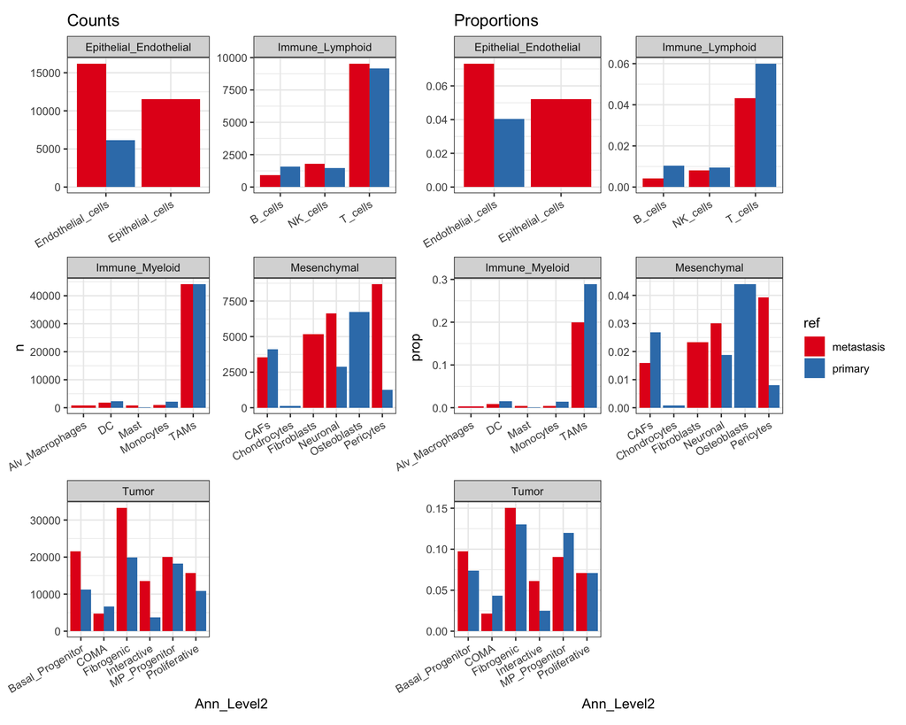

```r
make_barplot(prim_coldata, mets_coldata) |>
  wrap_plots(ncol=2, guides = "collect")
```

We see:

- Relatively more endothelial in mets, and no epithelial in primary
- Same immune lymphoid cell types but primary has relatively more T cells in the reference
- Similar immune myeloid distributions but primary has relatively more TAMs
- Most differences fall out in the mesenchymal cell types
- Same sets of tumor cells, but some different enrichments between references

### Heatmap

We’ll make a heatmap comparing expression across references.

We’ll compare `Ann_Level2` between primary and metastatic references by first aggregating them and then running `SingleR::matchReferences()` and plotting the resulting heatmap. This will tell us where cell type expression patterns overlap/differ between references. In particular, this function can help identify cases when different labels between references effectively point to the same cell type. As such, it does not just compare references with matching labels - it attempt to reconcile labels between references.

```r
matched <- matchReferences(
  patient_mets_aggr$ref,
  patient_prim_aggr$ref,
  patient_mets_aggr$labels$full,
  patient_prim_aggr$labels$full
)
```

First, we’ll show all cell types to help see if there is any correspondence between cell types in general between references, regardless of whether the label is shared:

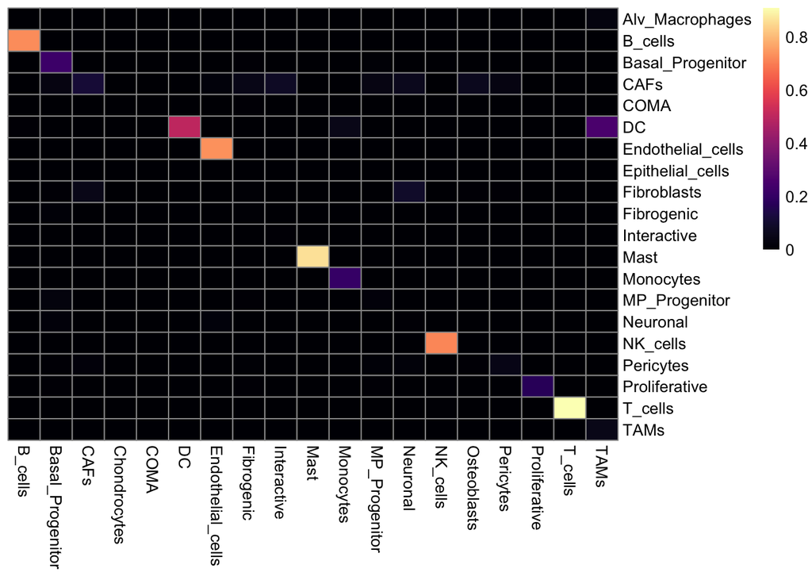

```r
pheatmap::pheatmap(
  matched,
  col=viridis::magma(500),
  cluster_rows = FALSE,
  cluster_cols = FALSE
)
```

Now, only the cell types shared between the references:

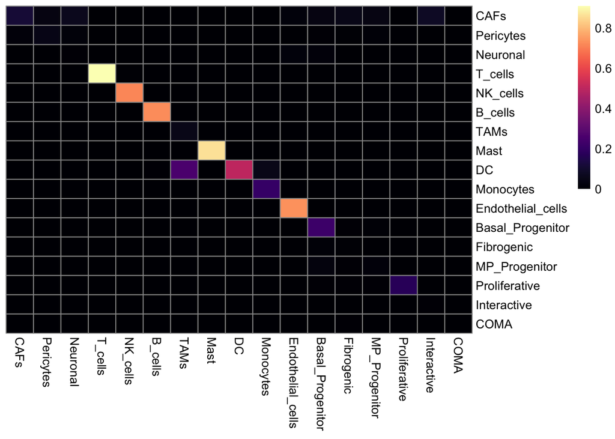

```r
shared_matched <- matched[shared, shared]
pheatmap::pheatmap(
  shared_matched,
  col=viridis::magma(500),
  cluster_rows = FALSE,
  cluster_cols = FALSE
)
```

It is clear that while most cell type labels are in both references, many of them have distinct expression patterns. Aside from TAMs, immune cells appear largely consistent, but many of the tumor cells are not (COMA, Interactive, MP_progenitor, Fibrogenic). But, even cell types with a clearly visible diagonal are not necessarily the highest on the color scale, which suggests differences are common. This means if we were to combine references, we want to still distinguish cell types by their source.

## Xenograft reference analysis

Next, we’ll do the same analysis with xenograft references. Note that there are many fewer cell types here, because the reference considers only human-derived tumor cells. `Ann_Level<0/1>` are the same (all “Tumor”) and `Ann_Level<2/3>` are the same for the xenograft references, so `Ann_Level2` is the most fine-grained we can achieve.

### Read references

We’ll read in and aggregate, extract `colData` so we can ditch these objects as soon as possible.

```r
xeno_prim <- readr::read_rds(file.path(ref_dir, "xeno_prim_sce.rds"))
xeno_prim_aggr <- SingleR::trainSingleR(
  ref = xeno_prim,
  labels = xeno_prim$Ann_Level2,
  de.method = "wilcox",
  aggr.ref = TRUE,
  BPPARAM = bp_param
)
prim_coldata <- colData(xeno_prim)
rm(xeno_prim)


xeno_mets <- readr::read_rds(file.path(ref_dir, "xeno_mets_sce.rds"))
xeno_mets_aggr <- SingleR::trainSingleR(
  ref = xeno_mets,
  labels = xeno_mets$Ann_Level2,
  de.method = "wilcox",
  aggr.ref = TRUE,
  BPPARAM = bp_param
)
mets_coldata <- colData(xeno_mets)
rm(xeno_mets)

gc()
```

```
            used  (Mb) gc trigger    (Mb) limit (Mb)   max used    (Mb)
Ncells   9118788 487.0   15411850   823.1         NA   15411850   823.1
Vcells 122207854 932.4 2306039404 17593.7      36864 3109861314 23726.4
```

### Reference cell types

What are the cell types within each reference? We’ll again make barplots of the counts and proportions for complementary views; there are few enough cell types that we don’t need a table.

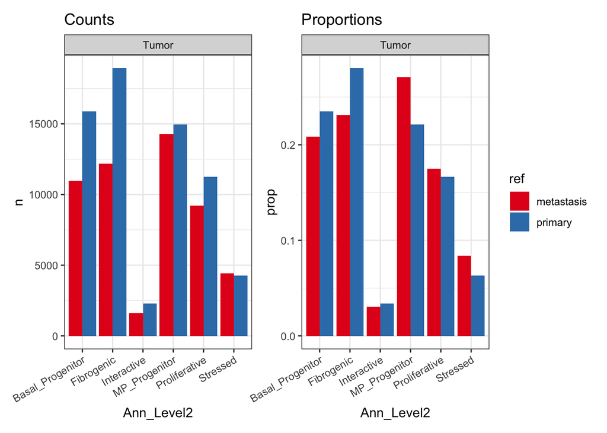

```r
make_barplot(prim_coldata, mets_coldata) |>
  wrap_plots(ncol=2, guides = "collect")
```

Distributions are not terribly different, though the primary reference has a bit more basal progenitor and fibrogenic cells, and the metastasis reference has more mp progenitor stressed cells. Interactive and proliferative have similar proportions.

### Heatmap

Now we’ll compare expression patterns of the cell types, which have the same labels in both references.

```r
matched <- matchReferences(
  xeno_mets_aggr$ref,
  xeno_prim_aggr$ref,
  xeno_mets_aggr$labels$full,
  xeno_prim_aggr$labels$full
)
```

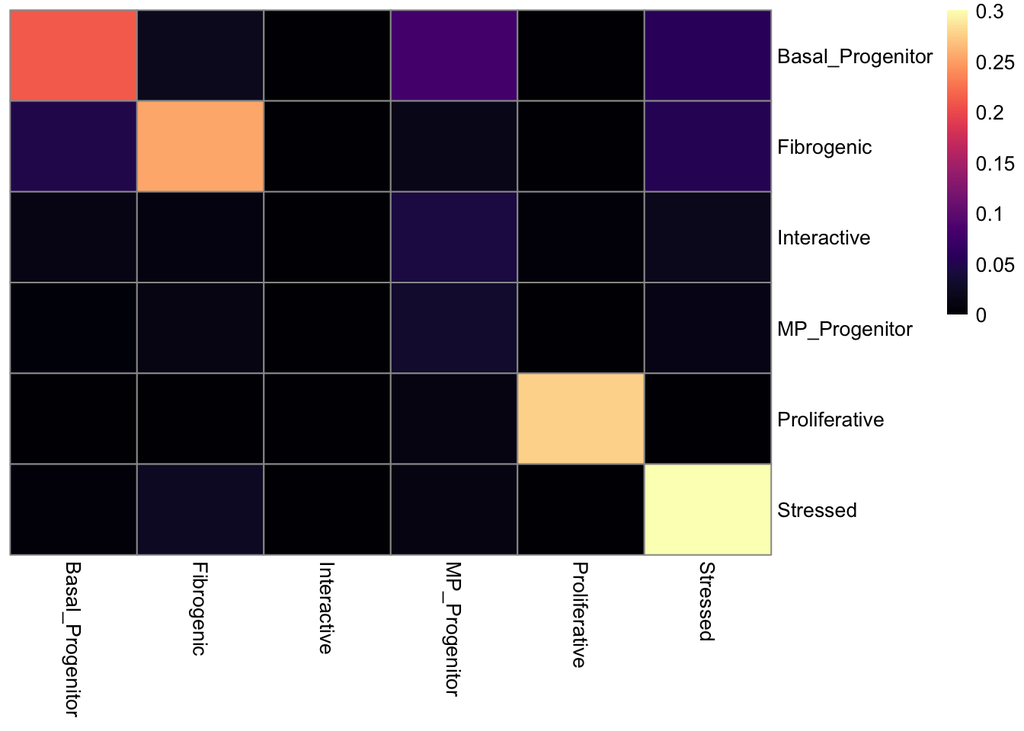

```r
pheatmap::pheatmap(
  matched,
  col=viridis::magma(500),
  cluster_rows = FALSE,
  cluster_cols = FALSE
)
```

## Conclusions

Given the differences between primary/metastasis references for both patients and xenografts, it seems worth doing some initial exploration of annotation performance with `SingleR` next.